# Model Comparison (TRBV MS)

SK

June 25, 2019

## Models

### M0: Zero-model Binomial regression

- $Y_{ij} \sim \operatorname{Binomial}(N_{i}, \theta_{ij})$
- $\theta_{ij} = \operatorname{logit^{-1}} (\alpha_{j} + \beta_{j} \cdot X_{i})$
- $\beta_{j} \sim \operatorname{Normal}(\hat{\beta}, \hat{\beta}_{\sigma})$
- $\alpha_{j} \sim \operatorname{Normal}(\hat{\alpha}, \hat{\alpha}_{\sigma})$
- $\hat{\beta} \sim \operatorname{Normal}(0, 5)$
- $\hat{\alpha} \sim \operatorname{Normal}(0, 20)$
- $\beta_{\sigma}, \hat{\alpha}_{\sigma} \sim \operatorname{Cauchy^{+}}(0, 3)$

### M1: Binomial regression

- $Y_{ij} \sim \operatorname{Binomial}(N_{i}, \theta_{ij})$
- $\theta_{ij} = \operatorname{logit^{-1}} (\alpha_{j} + \beta_{ij} \cdot X_{i})$
- $\beta_{ij} \sim \operatorname{Normal}(\gamma_{j}, \gamma_{\sigma})$
- $\gamma_{j} \sim \operatorname{Normal}(\hat{\gamma}, \hat{\gamma}_{\sigma})$
- $\alpha_{j} \sim \operatorname{Normal}(\hat{\alpha}, \hat{\alpha}_{\sigma})$
- $\hat{\gamma} \sim \operatorname{Normal}(0, 5)$
- $\hat{\alpha} \sim \operatorname{Normal}(0, 20)$
- $\gamma_{\sigma}, \hat{\gamma}_{\sigma}, \hat{\alpha}_{\sigma} \sim \operatorname{Cauchy^{+}}(0, 3)$

### M2: Zero-Inflated-Binomial (ZIB) regression

- cases for $Y_{ij}=$
- $0, \text{with } \pi_j$
- $\operatorname{Binomial}(N_{i}, \theta_{ij}), \text{with } 1-\pi_j$
- $\theta_{ij} = \operatorname{logit^{-1}} (\alpha_{j} + \beta_{ij} \cdot X_{i})$
- $\beta_{ij} \sim \operatorname{Normal}(\gamma_{j}, \gamma_{\sigma})$
- $\gamma_{j} \sim \operatorname{Normal}(\hat{\gamma}, \hat{\gamma}_{\sigma})$
- $\alpha_{j} \sim \operatorname{Normal}(\hat{\alpha}, \hat{\alpha}_{\sigma})$
- $\hat{\gamma} \sim \operatorname{Normal}(0, 5)$
- $\hat{\alpha} \sim \operatorname{Normal}(0, 20)$
- $\gamma_{\sigma}, \hat{\gamma}_{\sigma}, \hat{\alpha}_{\sigma} \sim \operatorname{Cauchy^{+}}(0, 3)$
- $\pi_j \sim \operatorname{Beta}(1, 1)$

### M3: Beta-binomial regression

- $Y_{ij} \sim \operatorname{Beta-Binomial}(N_{i}, \theta_{ij} \cdot \phi, (1 - \theta_{ij}) \cdot \phi)$
- $\theta_{ij} = \operatorname{logit^{-1}} (\alpha_{j} + \beta_{ij} \cdot X_{i})$
- $\beta_{ij} \sim \operatorname{Normal}(\gamma_{j}, \gamma_{\sigma})$
- $\gamma_{j} \sim \operatorname{Normal}(\hat{\gamma}, \hat{\gamma}_{\sigma})$
- $\alpha_{j} \sim \operatorname{Normal}(\hat{\alpha}, \hat{\alpha}_{\sigma})$
- $\hat{\gamma} \sim \operatorname{Normal}(0, 5)$
- $\hat{\alpha} \sim \operatorname{Normal}(0, 20)$
- $\gamma_{\sigma}, \hat{\gamma}_{\sigma}, \hat{\alpha}_{\sigma} \sim \operatorname{Cauchy^{+}}(0, 3)$
- $\phi \sim \operatorname{Gamma}(0.1, 0.1)$

## LOO

### M0

```
FALSE
FALSE Computed from 6000 by 1152 log-likelihood matrix
FALSE
FALSE           Estimate      SE
FALSE elpd_loo -337963.2 28177.9
FALSE p_loo      24763.8  1211.2
FALSE looic     675926.4 56355.9
FALSE ------
FALSE Monte Carlo SE of elpd_loo is NA.
FALSE
FALSE Pareto k diagnostic values:
FALSE                          Count Pct.    Min. n_eff
FALSE (-Inf, 0.5]   (good)     401   34.8%   254
FALSE  (0.5, 0.7]   (ok)        86    7.5%   68
FALSE    (0.7, 1]   (bad)      108    9.4%   12
FALSE    (1, Inf)   (very bad) 557   48.4%   1
FALSE See help('pareto-k-diagnostic') for details.
```

### M1

```
FALSE
FALSE Computed from 6000 by 1152 log-likelihood matrix
FALSE
FALSE          Estimate   SE
FALSE elpd_loo  -7021.3 30.3
FALSE p_loo       984.4 13.7
FALSE looic     14042.6 60.6
FALSE ------
FALSE Monte Carlo SE of elpd_loo is NA.
FALSE
FALSE Pareto k diagnostic values:
FALSE                          Count Pct.    Min. n_eff
FALSE (-Inf, 0.5]   (good)       0    0.0%   <NA>
FALSE  (0.5, 0.7]   (ok)        91    7.9%   199
FALSE    (0.7, 1]   (bad)      840   72.9%   19
FALSE    (1, Inf)   (very bad) 221   19.2%   2
FALSE See help('pareto-k-diagnostic') for details.
```

### M2

```
FALSE
FALSE Computed from 6000 by 1152 log-likelihood matrix
FALSE
FALSE          Estimate   SE
FALSE elpd_loo  -7065.4 30.5
FALSE p_loo       982.9 13.0
FALSE looic     14130.8 61.0
FALSE ------
FALSE Monte Carlo SE of elpd_loo is NA.
FALSE
FALSE Pareto k diagnostic values:
FALSE                          Count Pct.    Min. n_eff
FALSE (-Inf, 0.5]   (good)       0    0.0%   <NA>
FALSE  (0.5, 0.7]   (ok)        77    6.7%   190
FALSE    (0.7, 1]   (bad)      855   74.2%   20
FALSE    (1, Inf)   (very bad) 220   19.1%   3
FALSE See help('pareto-k-diagnostic') for details.
```

### M3

```
FALSE
FALSE Computed from 6000 by 1152 log-likelihood matrix
FALSE
FALSE          Estimate    SE
FALSE elpd_loo  -9742.5  57.5
FALSE p_loo       561.5  28.0
FALSE looic     19485.0 115.1
FALSE ------
FALSE Monte Carlo SE of elpd_loo is NA.
FALSE
FALSE Pareto k diagnostic values:
FALSE                          Count Pct.    Min. n_eff
FALSE (-Inf, 0.5]   (good)     386   33.5%   684
FALSE  (0.5, 0.7]   (ok)       409   35.5%   130
FALSE    (0.7, 1]   (bad)      316   27.4%   18
FALSE    (1, Inf)   (very bad)  41    3.6%   2
FALSE See help('pareto-k-diagnostic') for details.
```

### Comparison

```
FALSE                                        elpd_diff se_diff   elpd_loo
FALSE loo::loo(loo::extract_log_lik(M1$glm))       0.0       0.0   -7021.3
FALSE loo::loo(loo::extract_log_lik(M2$glm))     -44.1       7.3   -7065.4
FALSE loo::loo(loo::extract_log_lik(M3$glm))   -2721.2      38.1   -9742.5
FALSE loo::loo(loo::extract_log_lik(M0$glm)) -330941.9   28169.9 -337963.2
FALSE                                        p_loo     looic
FALSE loo::loo(loo::extract_log_lik(M1$glm))     984.4   14042.6
FALSE loo::loo(loo::extract_log_lik(M2$glm))     982.9   14130.8
FALSE loo::loo(loo::extract_log_lik(M3$glm))     561.5   19485.0
FALSE loo::loo(loo::extract_log_lik(M0$glm))   24763.8  675926.4
```

## PPC

### M0

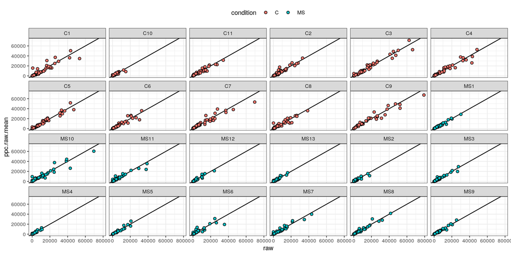

### M1

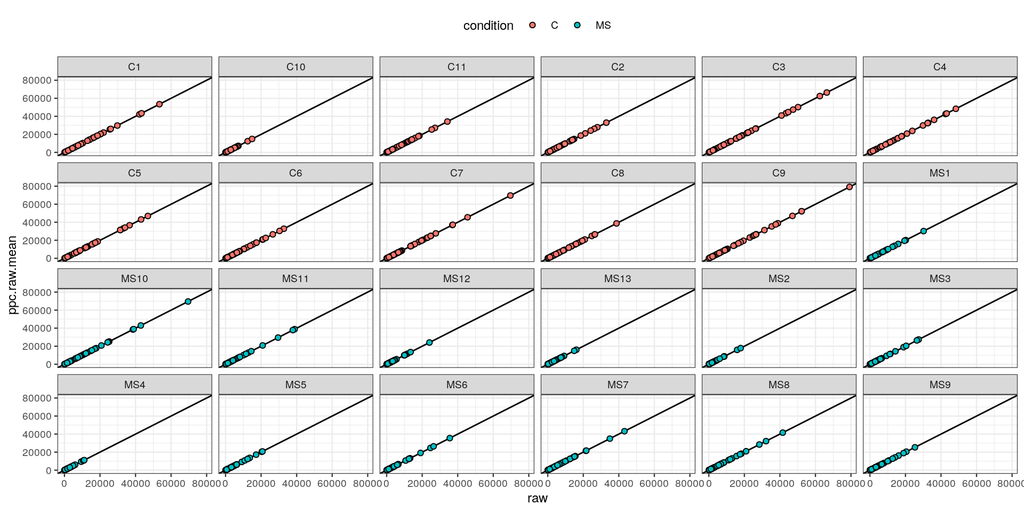

### M2

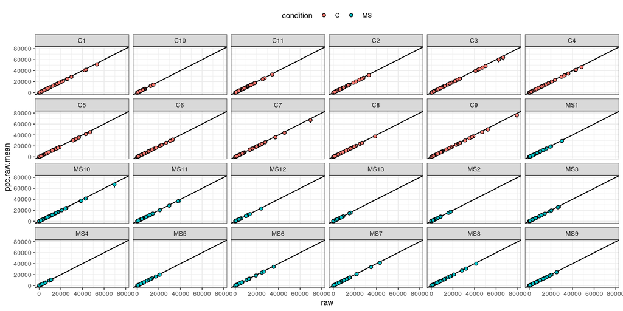

### M3

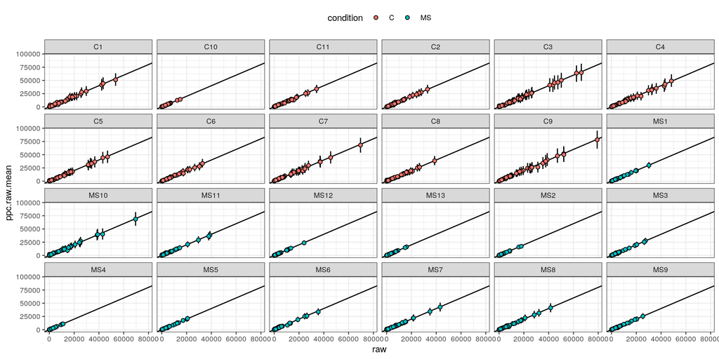

### Errors at a repertoire level

- e[%] = |Yhat[%] - Y[%| or
- e[raw count] = |Yhat[count] - Y[count]|

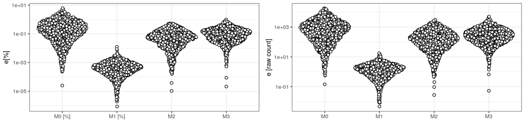

### Errors at a gene level

- raw mean in gene&condition vs ppc mean in gene&condition

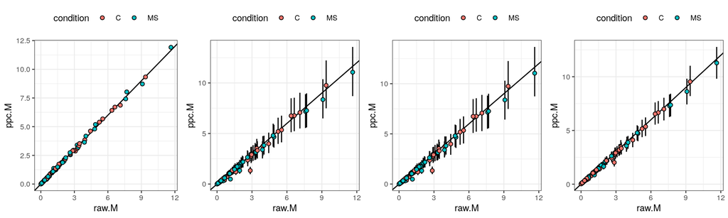